# Multi-Class Tabular Model for Dry Bean Identification Using Python and TensorFlow Decision Forests

### May 31, 2022

SUMMARY: The project aims to construct a predictive model using various machine learning algorithms and document the end-to-end steps using a template. The Dry Bean Identification dataset is a multi-class modeling situation where we attempt to predict one of several (more than two) possible outcomes.

INTRODUCTION: There is a wide range of genetic diversity in dry beans, the most produced one among the edible legume crops in the world. Seed classification is essential for the marketing and production of sustainable agricultural systems. The primary objective of this research study is to provide a method for obtaining uniform seed varieties from crop production. The research team developed a computer vision system to classify seven different types of dry beans with similar features. For the classification model, the researchers used a high-resolution camera to gather 13,611 images of dry beans.

CONCLUSION: In this iteration, the TensorFlow Decision Forests model appeared to be a suitable algorithm for modeling this dataset.

Dataset Used: Dry Bean Dataset

Dataset ML Model: Multi-Class classification with numerical features

Dataset Reference: https://www.muratkoklu.com/datasets/

One source of potential performance benchmarks: https://doi.org/10.1016/j.compag.2020.105507

## Task 1 - Prepare Environment

```python
# Install TensorFlow Decision Forests.
!pip3 install tensorflow_decision_forests --upgrade
```

```python
# Retrieve the CPU information
ncpu = !nproc
print("The number of available CPUs is:", ncpu[0])
```

```
The number of available CPUs is: 2
```

### 1.a) Load libraries and modules

```python
# Set the random seed number for reproducible results
RNG_SEED = 888
```

```python
import random
random.seed(RNG_SEED)
import numpy as np
np.random.seed(RNG_SEED)
import pandas as pd
import seaborn as sns
import matplotlib
import matplotlib.pyplot as plt
import os
import sys
import math
# import boto3
import zipfile
from datetime import datetime
from sklearn import preprocessing
from sklearn.model_selection import train_test_split
from sklearn.model_selection import RepeatedKFold
from sklearn.metrics import classification_report
from sklearn.metrics import confusion_matrix
from sklearn.metrics import accuracy_score
from sklearn.pipeline import Pipeline
from sklearn import compose
from sklearn import impute
from sklearn import metrics
import tensorflow as tf
tf.random.set_seed(RNG_SEED)
# from tensorflow import keras
import tensorflow_decision_forests as tfdf
```

```
WARNING:root:TF Parameter Server distributed training not available (this is expected for the pre-build release).
```

### 1.b) Set up the controlling parameters and functions

```python
# Begin the timer for the script processing
start_time_script = datetime.now()

# Set up the number of CPU cores available for multi-thread processing
N_JOBS = 1

# Set up the flag to stop sending progress emails (setting to True will send status emails!)
NOTIFY_STATUS = False

# Set the percentage sizes for splitting the dataset
TEST_SET_RATIO = 0.1
VAL_SET_RATIO = 0.1

# Set the name for the class/label column
ORIGINAL_LABEL = 'Class'
CLASS_COLUMN = 'target'

# Set the number of folds for cross validation
N_FOLDS = 5
N_ITERATIONS = 1

# Set various default modeling parameters
DEFAULT_METRICS = ["accuracy", tf.keras.metrics.SparseCategoricalCrossentropy()]

# Define the directory locations and file names
TRAIN_DATASET = 'Durum_Wheat_Features.csv'

# Print out the TensorFlow version for confirmation
print('TensorFlow version:', tf.__version__)

# Check the version of TensorFlow Decision Forests
print("Found TensorFlow Decision Forests v" + tfdf.__version__)
```

```
TensorFlow version: 2.9.0
Found TensorFlow Decision Forests v0.2.5
```

```python
# Set up the email notification function
def status_notify(msg_text):
    access_key = os.environ.get('SNS_ACCESS_KEY')
    secret_key = os.environ.get('SNS_SECRET_KEY')
    aws_region = os.environ.get('SNS_AWS_REGION')
    topic_arn = os.environ.get('SNS_TOPIC_ARN')
    if (access_key is None) or (secret_key is None) or (aws_region is None):
        sys.exit("Incomplete notification setup info. Script Processing Aborted!!!")
    sns = boto3.client('sns', aws_access_key_id=access_key, aws_secret_access_key=secret_key, region_name=aws_region)
    response = sns.publish(TopicArn=topic_arn, Message=msg_text)
    if response['ResponseMetadata']['HTTPStatusCode'] != 200 :
        print('Status notification not OK with HTTP status code:', response['ResponseMetadata']['HTTPStatusCode'])
```

```python
if NOTIFY_STATUS: status_notify("Task 1 - Prepare Environment has begun! " + datetime.now().strftime('%a %B %d, %Y %I:%M:%S %p'))
```

### 1.c) Load dataset

```python
dataset_path = 'https://dainesanalytics.com/datasets/muratkoklu-dry-bean-dataset/Dry_Bean_Dataset.arff'
colNames = ['Area','Perimeter','MajorAxisLength','MinorAxisLength','AspectRation','Eccentricity','Convex_Area','EquivDiameter',
            'Extent','Solidity','Roundness','Compactness','ShapeFactor1','ShapeFactor2','ShapeFactor3','ShapeFactor4','Class']
df_dataset_import = pd.read_csv(dataset_path, names=colNames, sep=',', header=None, index_col=False, skiprows=25)

# Take a peek at the dataframe after import
print(df_dataset_import.head())
```

```
    Area  Perimeter  MajorAxisLength  MinorAxisLength  AspectRation  \
0  28395    610.291       208.178117       173.888747      1.197191
1  28734    638.018       200.524796       182.734419      1.097356
2  29380    624.110       212.826130       175.931143      1.209713
3  30008    645.884       210.557999       182.516516      1.153638
4  30140    620.134       201.847882       190.279279      1.060798

   Eccentricity  Convex_Area  EquivDiameter    Extent  Solidity  Roundness  \
0      0.549812        28715     190.141097  0.763923  0.988856   0.958027
1      0.411785        29172     191.272750  0.783968  0.984986   0.887034
2      0.562727        29690     193.410904  0.778113  0.989559   0.947849
3      0.498616        30724     195.467062  0.782681  0.976696   0.903936
4      0.333680        30417     195.896503  0.773098  0.990893   0.984877

   Compactness  ShapeFactor1  ShapeFactor2  ShapeFactor3  ShapeFactor4  Class
0     0.913358      0.007332      0.003147      0.834222      0.998724  SEKER
1     0.953861      0.006979      0.003564      0.909851      0.998430  SEKER
2     0.908774      0.007244      0.003048      0.825871      0.999066  SEKER
3     0.928329      0.007017      0.003215      0.861794      0.994199  SEKER
4     0.970516      0.006697      0.003665      0.941900      0.999166  SEKER
```

```python
df_dataset_import.info(verbose=True)
```

```
<class 'pandas.core.frame.DataFrame'>
RangeIndex: 13611 entries, 0 to 13610
Data columns (total 17 columns):
 #   Column           Non-Null Count  Dtype
---  ------           --------------  -----
 0   Area             13611 non-null  int64
 1   Perimeter        13611 non-null  float64
 2   MajorAxisLength  13611 non-null  float64
 3   MinorAxisLength  13611 non-null  float64
 4   AspectRation     13611 non-null  float64
 5   Eccentricity     13611 non-null  float64
 6   Convex_Area      13611 non-null  int64
 7   EquivDiameter    13611 non-null  float64
 8   Extent           13611 non-null  float64
 9   Solidity         13611 non-null  float64
 10  Roundness        13611 non-null  float64
 11  Compactness      13611 non-null  float64
 12  ShapeFactor1     13611 non-null  float64
 13  ShapeFactor2     13611 non-null  float64
 14  ShapeFactor3     13611 non-null  float64
 15  ShapeFactor4     13611 non-null  float64
 16  Class            13611 non-null  object
dtypes: float64(14), int64(2), object(1)
memory usage: 1.8+ MB
```

```python
print(df_dataset_import.describe())
```

```
                Area     Perimeter  MajorAxisLength  MinorAxisLength  \
count   13611.000000  13611.000000     13611.000000     13611.000000
mean    53048.284549    855.283459       320.141867       202.270714
std     29324.095717    214.289696        85.694186        44.970091
min     20420.000000    524.736000       183.601165       122.512653
25%     36328.000000    703.523500       253.303633       175.848170
50%     44652.000000    794.941000       296.883367       192.431733
75%     61332.000000    977.213000       376.495012       217.031741
max    254616.000000   1985.370000       738.860153       460.198497

       AspectRation  Eccentricity    Convex_Area  EquivDiameter        Extent  \
count  13611.000000  13611.000000   13611.000000   13611.000000  13611.000000
mean       1.583242      0.750895   53768.200206     253.064220      0.749733
std        0.246678      0.092002   29774.915817      59.177120      0.049086
min        1.024868      0.218951   20684.000000     161.243764      0.555315
25%        1.432307      0.715928   36714.500000     215.068003      0.718634
50%        1.551124      0.764441   45178.000000     238.438026      0.759859
75%        1.707109      0.810466   62294.000000     279.446467      0.786851
max        2.430306      0.911423  263261.000000     569.374358      0.866195

           Solidity     Roundness   Compactness  ShapeFactor1  ShapeFactor2  \
count  13611.000000  13611.000000  13611.000000  13611.000000  13611.000000
mean       0.987143      0.873282      0.799864      0.006564      0.001716
std        0.004660      0.059520      0.061713      0.001128      0.000596
min        0.919246      0.489618      0.640577      0.002778      0.000564
25%        0.985670      0.832096      0.762469      0.005900      0.001154
50%        0.988283      0.883157      0.801277      0.006645      0.001694
75%        0.990013      0.916869      0.834270      0.007271      0.002170
max        0.994677      0.990685      0.987303      0.010451      0.003665

       ShapeFactor3  ShapeFactor4
count  13611.000000  13611.000000
mean       0.643590      0.995063
std        0.098996      0.004366
min        0.410339      0.947687
25%        0.581359      0.993703
50%        0.642044      0.996386
75%        0.696006      0.997883
max        0.974767      0.999733
```

```python
print(df_dataset_import.isnull().sum())
print('Total number of NaN in the dataframe: ', df_dataset_import.isnull().sum().sum())
```

```
Area               0
Perimeter          0
MajorAxisLength    0
MinorAxisLength    0
AspectRation       0
Eccentricity       0
Convex_Area        0
EquivDiameter      0
Extent             0
Solidity           0
Roundness          0
Compactness        0
ShapeFactor1       0
ShapeFactor2       0
ShapeFactor3       0
ShapeFactor4       0
Class              0
dtype: int64
Total number of NaN in the dataframe:  0
```

```python
# Get grouping size for the target variable
print(df_dataset_import.groupby(ORIGINAL_LABEL).size())
```

```
Class
BARBUNYA    1322
BOMBAY       522
CALI        1630
DERMASON    3546
HOROZ       1928
SEKER       2027
SIRA        2636
dtype: int64
```

### 1.d) Data Cleaning

```python
# Standardize the class column to the name of targetVar if required
df_dataset_import = df_dataset_import.rename(columns={ORIGINAL_LABEL: CLASS_COLUMN})

# Transform the classes into integers
label_encoder = preprocessing.LabelEncoder()
df_dataset_import[CLASS_COLUMN] = label_encoder.fit_transform(df_dataset_import[CLASS_COLUMN])

# Take a peek at the dataframe after cleaning
print(df_dataset_import.head())
```

```
    Area  Perimeter  MajorAxisLength  MinorAxisLength  AspectRation  \
0  28395    610.291       208.178117       173.888747      1.197191
1  28734    638.018       200.524796       182.734419      1.097356
2  29380    624.110       212.826130       175.931143      1.209713
3  30008    645.884       210.557999       182.516516      1.153638
4  30140    620.134       201.847882       190.279279      1.060798

   Eccentricity  Convex_Area  EquivDiameter    Extent  Solidity  Roundness  \
0      0.549812        28715     190.141097  0.763923  0.988856   0.958027
1      0.411785        29172     191.272750  0.783968  0.984986   0.887034
2      0.562727        29690     193.410904  0.778113  0.989559   0.947849
3      0.498616        30724     195.467062  0.782681  0.976696   0.903936
4      0.333680        30417     195.896503  0.773098  0.990893   0.984877

   Compactness  ShapeFactor1  ShapeFactor2  ShapeFactor3  ShapeFactor4  target
0     0.913358      0.007332      0.003147      0.834222      0.998724       5
1     0.953861      0.006979      0.003564      0.909851      0.998430       5
2     0.908774      0.007244      0.003048      0.825871      0.999066       5
3     0.928329      0.007017      0.003215      0.861794      0.994199       5
4     0.970516      0.006697      0.003665      0.941900      0.999166       5
```

```python
df_dataset_import.info(verbose=True)
```

```
<class 'pandas.core.frame.DataFrame'>
RangeIndex: 13611 entries, 0 to 13610
Data columns (total 17 columns):
 #   Column           Non-Null Count  Dtype
---  ------           --------------  -----
 0   Area             13611 non-null  int64
 1   Perimeter        13611 non-null  float64
 2   MajorAxisLength  13611 non-null  float64
 3   MinorAxisLength  13611 non-null  float64
 4   AspectRation     13611 non-null  float64
 5   Eccentricity     13611 non-null  float64
 6   Convex_Area      13611 non-null  int64
 7   EquivDiameter    13611 non-null  float64
 8   Extent           13611 non-null  float64
 9   Solidity         13611 non-null  float64
 10  Roundness        13611 non-null  float64
 11  Compactness      13611 non-null  float64
 12  ShapeFactor1     13611 non-null  float64
 13  ShapeFactor2     13611 non-null  float64
 14  ShapeFactor3     13611 non-null  float64
 15  ShapeFactor4     13611 non-null  float64
 16  target           13611 non-null  int64
dtypes: float64(14), int64(3)
memory usage: 1.8 MB
```

```python
print(df_dataset_import.describe())
```

```
                Area     Perimeter  MajorAxisLength  MinorAxisLength  \
count   13611.000000  13611.000000     13611.000000     13611.000000
mean    53048.284549    855.283459       320.141867       202.270714
std     29324.095717    214.289696        85.694186        44.970091
min     20420.000000    524.736000       183.601165       122.512653
25%     36328.000000    703.523500       253.303633       175.848170
50%     44652.000000    794.941000       296.883367       192.431733
75%     61332.000000    977.213000       376.495012       217.031741
max    254616.000000   1985.370000       738.860153       460.198497

       AspectRation  Eccentricity    Convex_Area  EquivDiameter        Extent  \
count  13611.000000  13611.000000   13611.000000   13611.000000  13611.000000
mean       1.583242      0.750895   53768.200206     253.064220      0.749733
std        0.246678      0.092002   29774.915817      59.177120      0.049086
min        1.024868      0.218951   20684.000000     161.243764      0.555315
25%        1.432307      0.715928   36714.500000     215.068003      0.718634
50%        1.551124      0.764441   45178.000000     238.438026      0.759859
75%        1.707109      0.810466   62294.000000     279.446467      0.786851
max        2.430306      0.911423  263261.000000     569.374358      0.866195

           Solidity     Roundness   Compactness  ShapeFactor1  ShapeFactor2  \
count  13611.000000  13611.000000  13611.000000  13611.000000  13611.000000
mean       0.987143      0.873282      0.799864      0.006564      0.001716
std        0.004660      0.059520      0.061713      0.001128      0.000596
min        0.919246      0.489618      0.640577      0.002778      0.000564
25%        0.985670      0.832096      0.762469      0.005900      0.001154
50%        0.988283      0.883157      0.801277      0.006645      0.001694
75%        0.990013      0.916869      0.834270      0.007271      0.002170
max        0.994677      0.990685      0.987303      0.010451      0.003665

       ShapeFactor3  ShapeFactor4        target
count  13611.000000  13611.000000  13611.000000
mean       0.643590      0.995063      3.532657
std        0.098996      0.004366      1.828709
min        0.410339      0.947687      0.000000
25%        0.581359      0.993703      2.000000
50%        0.642044      0.996386      3.000000
75%        0.696006      0.997883      5.000000
max        0.974767      0.999733      6.000000
```

```python
print(df_dataset_import.isnull().sum())
print('Total number of NaN in the dataframe: ', df_dataset_import.isnull().sum().sum())
```

```
Area               0
Perimeter          0
MajorAxisLength    0
MinorAxisLength    0
AspectRation       0
Eccentricity       0
Convex_Area        0
EquivDiameter      0
Extent             0
Solidity           0
Roundness          0
Compactness        0
ShapeFactor1       0
ShapeFactor2       0
ShapeFactor3       0
ShapeFactor4       0
target             0
dtype: int64
Total number of NaN in the dataframe:  0
```

```python
# Get grouping size for the target variable
print(df_dataset_import.groupby(CLASS_COLUMN).size())
```

```
target
0    1322
1     522
2    1630
3    3546
4    1928
5    2027
6    2636
dtype: int64
```

### 1.e) Splitting Data into Sets

```python
# Use variable total_column_count to hold the number of columns in the dataframe
total_column_count = len(df_dataset_import.columns)

# Set up variable total_feature_count for the total number of attribute columns
total_feature_count = total_column_count-1

# We create attribute-only and target-only datasets (df_features_train and df_target_train)
df_target_import = df_dataset_import['target']
df_features_import = df_dataset_import.drop(['target'], axis=1)

print("df_dataset_import.shape: {} df_features_import.shape: {} df_target_import.shape: {}".format(df_dataset_import.shape, df_features_import.shape, df_target_import.shape))
```

```
df_dataset_import.shape: (13611, 17) df_features_import.shape: (13611, 16) df_target_import.shape: (13611,)
```

```python
# Split the data further into training and test datasets
df_features_train, df_features_test, df_target_train, df_target_test = train_test_split(df_features_import, df_target_import,
                                                                                        test_size=TEST_SET_RATIO, random_state=RNG_SEED,
                                                                                        stratify=df_target_import)
print("df_features_train.shape: {} df_target_train.shape: {}".format(df_features_train.shape, df_target_train.shape))
print("df_features_test.shape: {} df_target_test.shape: {}".format(df_features_test.shape, df_target_test.shape))
```

```
df_features_train.shape: (12249, 16) df_target_train.shape: (12249,)
df_features_test.shape: (1362, 16) df_target_test.shape: (1362,)
```

### 1.f) Set up the parameters for data visualization

```python
# Set up the number of row and columns for visualization display. display_rows * display_columns should be >= total_feature_count
display_columns = 4
if total_feature_count % display_columns == 0 :
    display_rows = total_feature_count // display_columns
else :
    display_rows = (total_feature_count // display_columns) + 1

# Set figure width to display the data visualization plots
fig_size = plt.rcParams["figure.figsize"]
fig_size[0] = display_columns * 4
fig_size[1] = display_rows * 4
plt.rcParams["figure.figsize"] = fig_size
```

```python
if NOTIFY_STATUS: status_notify("Task 1 - Prepare Environment completed! "+datetime.now().strftime('%a %B %d, %Y %I:%M:%S %p'))
```

## Task 2 - Summarize and Visualize Data

```python
if NOTIFY_STATUS: status_notify("Task 2 - Summarize and Visualize Data has begun! "+datetime.now().strftime('%a %B %d, %Y %I:%M:%S %p'))
```

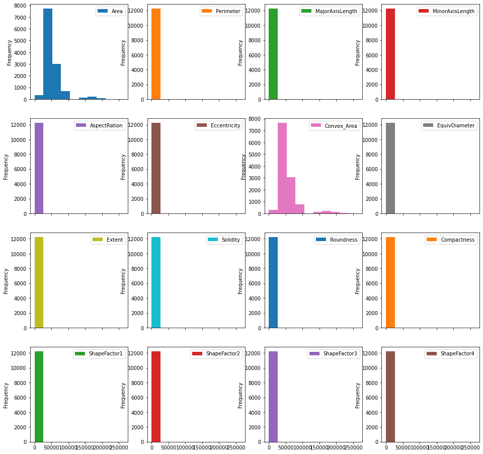

```python
# Histograms for each attribute
df_features_train.plot(kind='hist', subplots=True, layout=(display_rows, display_columns))
plt.show()
```

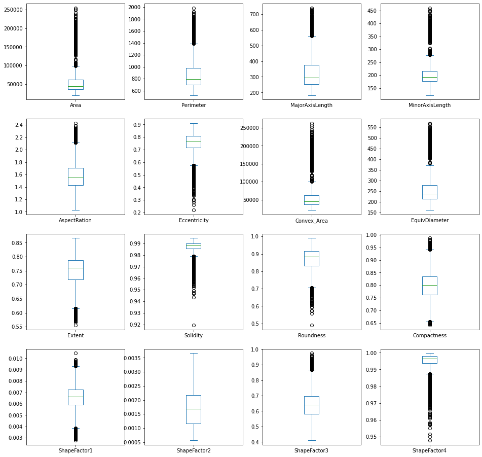

```python
# Box and Whisker plot for each attribute
df_features_train.plot(kind='box', subplots=True, layout=(display_rows, display_columns))
plt.show()
```

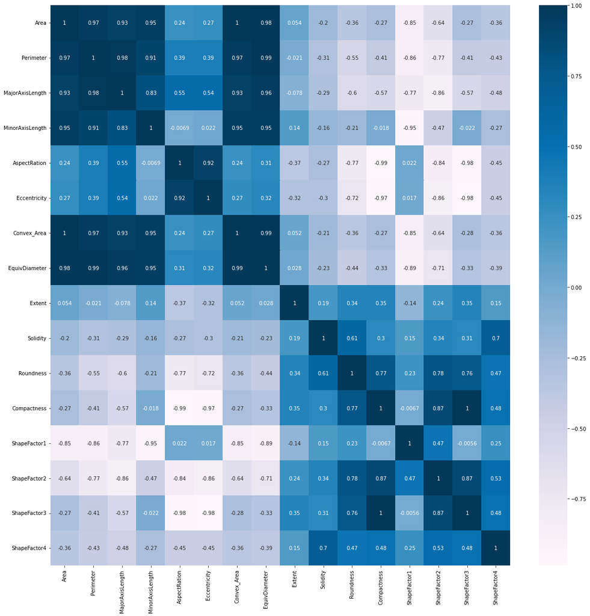

```python
# Correlation matrix
fig = plt.figure(figsize=(20, 20))
correlations = df_features_train.corr(method='pearson')
sns.heatmap(correlations, annot=True, cmap=plt.cm.PuBu)
plt.show()
```

```python
if NOTIFY_STATUS: status_notify("Task 2 - Summarize and Visualize Data completed! "+datetime.now().strftime('%a %B %d, %Y %I:%M:%S %p'))
```

## Task 3 - Train and Evaluate Models

```python
if NOTIFY_STATUS: status_notify("Task 3 - Train and Evaluate Models has begun! "+datetime.now().strftime('%a %B %d, %Y %I:%M:%S %p'))
```

### 3.a) Splitting Data into Training and Validation Sets

```python
# Finalize the training and validation datasets for the modeling activities
tfds_train = tfdf.keras.pd_dataframe_to_tf_dataset(df_dataset_import, label='target', task = tfdf.keras.Task.CLASSIFICATION)
```

### 3.b) Train and Evaluate the Random Forest Model

```python
# Define the baseline model for benchmarking
start_time_module = datetime.now()
tf.keras.utils.set_random_seed(RNG_SEED)
RF_model = tfdf.keras.RandomForestModel(task = tfdf.keras.Task.CLASSIFICATION)
RF_model.compile(metrics=DEFAULT_METRICS)

# "sys_pipes" is optional. It enables the display of the training logs.
# with sys_pipes():
#     RF_model.fit(x=tfds_train)

# Train the model.
RF_model.fit(x=tfds_train)
print ('Model training time:', (datetime.now() - start_time_module), '\n')
```

```
Use /tmp/tmpkeya45wf as temporary training directory
Reading training dataset...
Training dataset read in 0:00:13.991935. Found 13611 examples.
Training model...
Model trained in 0:00:28.777600
Compiling model...
WARNING:tensorflow:AutoGraph could not transform <function simple_ml_inference_op_with_handle at 0x7f2799dad830> and will run it as-is.
Please report this to the TensorFlow team. When filing the bug, set the verbosity to 10 (on Linux, `export AUTOGRAPH_VERBOSITY=10`) and attach the full output.
Cause: could not get source code
To silence this warning, decorate the function with @tf.autograph.experimental.do_not_convert
```

[output not shown]

[output not shown]

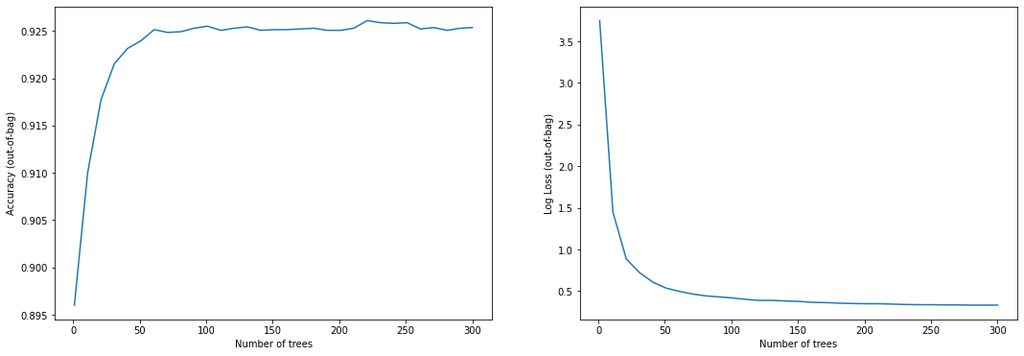

```python
logs = RF_model.make_inspector().training_logs()

plt.figure(figsize=(18, 6))
plt.subplot(1, 2, 1)
plt.plot([log.num_trees for log in logs], [log.evaluation.accuracy for log in logs])
plt.xlabel("Number of trees")
plt.ylabel("Accuracy (out-of-bag)")
plt.subplot(1, 2, 2)
plt.plot([log.num_trees for log in logs], [log.evaluation.loss for log in logs])
plt.xlabel("Number of trees")
plt.ylabel("Log Loss (out-of-bag)")
plt.show()
```

```python
RF_eval = RF_model.evaluate(tfds_train, return_dict=True)
print()

for name, value in RF_eval.items():
    print(f"{name}: {value:.4f}")
```

```
loss: 0.0000
accuracy: 0.9726
sparse_categorical_crossentropy: 0.0864
```

### 3.c) Train and Evaluate the Decision Trees Model

```python
# Define the baseline model for benchmarking
start_time_module = datetime.now()
tf.keras.utils.set_random_seed(RNG_SEED)
CART_model = tfdf.keras.CartModel(task = tfdf.keras.Task.CLASSIFICATION)
CART_model.compile(metrics=DEFAULT_METRICS)

# "sys_pipes" is optional. It enables the display of the training logs.
# with sys_pipes():
#     CART_model.fit(x=tfds_train)

# Train the model.
CART_model.fit(x=tfds_train)
print ('Model training time:', (datetime.now() - start_time_module), '\n')
```

```
Use /tmp/tmphq0f4n71 as temporary training directory
Reading training dataset...
Training dataset read in 0:00:00.417342. Found 13611 examples.
Training model...
Model trained in 0:00:00.148323
Compiling model...
Model compiled.
Model training time: 0:00:00.824166
```

```python
CART_eval = CART_model.evaluate(tfds_train, return_dict=True)
print()

for name, value in CART_eval.items():
    print(f"{name}: {value:.4f}")
```

```
loss: 0.0000
accuracy: 0.9347
sparse_categorical_crossentropy: 0.1522
```

### 3.d) Train and Evaluate the Gradient Boosted Trees Model

```python
# Define the baseline model for benchmarking
start_time_module = datetime.now()
tf.keras.utils.set_random_seed(RNG_SEED)
GBT_model = tfdf.keras.GradientBoostedTreesModel(task = tfdf.keras.Task.CLASSIFICATION)
GBT_model.compile(metrics=DEFAULT_METRICS)

# "sys_pipes" is optional. It enables the display of the training logs.
# with sys_pipes():
#     GBT_model.fit(x=tfds_train)

# Train the model.
GBT_model.fit(x=tfds_train)
print ('Model training time:', (datetime.now() - start_time_module), '\n')
```

```
Use /tmp/tmpl8uavfif as temporary training directory
Reading training dataset...
Training dataset read in 0:00:00.475201. Found 13611 examples.
Training model...
Model trained in 0:00:18.623179
Compiling model...
Model compiled.
Model training time: 0:00:20.846287
```

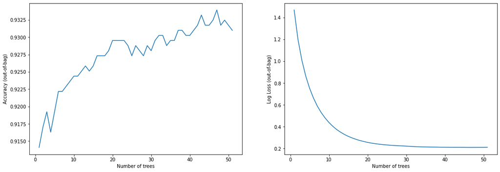

```python
logs = GBT_model.make_inspector().training_logs()

plt.figure(figsize=(18, 6))
plt.subplot(1, 2, 1)
plt.plot([log.num_trees for log in logs], [log.evaluation.accuracy for log in logs])
plt.xlabel("Number of trees")
plt.ylabel("Accuracy (out-of-bag)")
plt.subplot(1, 2, 2)
plt.plot([log.num_trees for log in logs], [log.evaluation.loss for log in logs])
plt.xlabel("Number of trees")
plt.ylabel("Log Loss (out-of-bag)")
plt.show()
```

```python
GBT_eval = GBT_model.evaluate(tfds_train, return_dict=True)
print()

for name, value in GBT_eval.items():
    print(f"{name}: {value:.4f}")
```

```
loss: 0.0000
accuracy: 0.9635
sparse_categorical_crossentropy: 0.1376
```

```python
if NOTIFY_STATUS: status_notify("Task 4 - Train and Evaluate Models completed! "+datetime.now().strftime('%a %B %d, %Y %I:%M:%S %p'))
```

## Task 4 - Fine-tune and Improve Models

```python
if NOTIFY_STATUS: status_notify("Task 4 - Fine-tune and Improve Models has begun! "+datetime.now().strftime('%a %B %d, %Y %I:%M:%S %p'))
```

```python
# Not applicable for this iteration of modeling
```

```python
if NOTIFY_STATUS: status_notify("Task 4 - Fine-tune and Improve Models completed! "+datetime.now().strftime('%a %B %d, %Y %I:%M:%S %p'))
```

## Task 5 - Finalize Model and Present Analysis

```python
if NOTIFY_STATUS: status_notify("Task 5 - Finalize Model and Present Analysis has begun! "+datetime.now().strftime('%a %B %d, %Y %I:%M:%S %p'))
```

### 5.a) Train the Final Model

```python
# Define the baseline model for benchmarking
start_time_module = datetime.now()
tf.keras.utils.set_random_seed(RNG_SEED)
final_model = tfdf.keras.RandomForestModel(task = tfdf.keras.Task.CLASSIFICATION)
# final_model = tfdf.keras.CartModel(task = tfdf.keras.Task.CLASSIFICATION)
# final_model = tfdf.keras.GradientBoostedTreesModel(task = tfdf.keras.Task.CLASSIFICATION)

# Optionally, add evaluation metrics.
final_model.compile(metrics=DEFAULT_METRICS)

# "sys_pipes" is optional. It enables the display of the training logs.
# with sys_pipes():
#     final_model.fit(x=tfds_train)

# Train the model.
final_model.fit(x=tfds_train)
print ('Model training time:', (datetime.now() - start_time_module), '\n')
```

```
Use /tmp/tmpjipk1pdo as temporary training directory
Reading training dataset...
Training dataset read in 0:00:00.451452. Found 13611 examples.
Training model...
Model trained in 0:00:24.864333
Compiling model...
Model compiled.
Model training time: 0:00:25.828260
```

```python
final_model.summary()
```

```
Model: "random_forest_model_1"
_________________________________________________________________
 Layer (type)                Output Shape              Param #
=================================================================
=================================================================
Total params: 1
Trainable params: 0
Non-trainable params: 1
_________________________________________________________________
Type: "RANDOM_FOREST"
Task: CLASSIFICATION
Label: "__LABEL"

Input Features (16):
	Area
	AspectRation
	Compactness
	Convex_Area
	Eccentricity
	EquivDiameter
	Extent
	MajorAxisLength
	MinorAxisLength
	Perimeter
	Roundness
	ShapeFactor1
	ShapeFactor2
	ShapeFactor3
	ShapeFactor4
	Solidity

No weights

Variable Importance: MEAN_MIN_DEPTH:
    1.         "__LABEL" 10.652006 ################
    2.          "Extent"  9.651784 ############
    3.        "Solidity"  8.914803 ##########
    4.    "Eccentricity"  8.444421 #########
    5.    "AspectRation"  8.340849 ########
    6.    "ShapeFactor4"  8.061871 #######
```

[output cut: 264 more lines]

```
	trees: 161, Out-of-bag evaluation: accuracy:0.925134 logloss:0.364656
	trees: 171, Out-of-bag evaluation: accuracy:0.925208 logloss:0.362104
	trees: 181, Out-of-bag evaluation: accuracy:0.925281 logloss:0.355326
	trees: 191, Out-of-bag evaluation: accuracy:0.925061 logloss:0.350872
	trees: 201, Out-of-bag evaluation: accuracy:0.925061 logloss:0.348535
	trees: 211, Out-of-bag evaluation: accuracy:0.925281 logloss:0.348514
	trees: 221, Out-of-bag evaluation: accuracy:0.926089 logloss:0.34382
	trees: 231, Out-of-bag evaluation: accuracy:0.925869 logloss:0.339229
	trees: 241, Out-of-bag evaluation: accuracy:0.925795 logloss:0.336813
	trees: 251, Out-of-bag evaluation: accuracy:0.925869 logloss:0.336604
	trees: 261, Out-of-bag evaluation: accuracy:0.925208 logloss:0.334202
	trees: 271, Out-of-bag evaluation: accuracy:0.925354 logloss:0.33407
	trees: 281, Out-of-bag evaluation: accuracy:0.925061 logloss:0.331757
	trees: 291, Out-of-bag evaluation: accuracy:0.925281 logloss:0.33184
	trees: 300, Out-of-bag evaluation: accuracy:0.925354 logloss:0.331877
```

### 5.b) Load Test Dataset and Make Predictions

```python
# Finalize the test dataset for the prediction activities
tfds_test = tfdf.keras.pd_dataframe_to_tf_dataset(df_features_test, task = tfdf.keras.Task.CLASSIFICATION)
```

```python
# Finalize the test dataset for the testing activities
array_target_test = df_target_test.ravel()
print("Shape of df_target_test: {}".format(array_target_test.shape))
```

```
Shape of df_target_test: (1362,)
```

```python
# Make batched predictions
# test_predictions = label_encoder.inverse_transform(np.argmax(final_model.predict(tfds_test), axis=-1))
test_predictions = np.argmax(final_model.predict(tfds_test), axis=-1)
print(test_predictions)
```

[output not shown]

[output not shown]

```
[6 2 6 ... 4 0 5]
```

```python
print('Accuracy Score:', accuracy_score(array_target_test, test_predictions))
print(confusion_matrix(array_target_test, test_predictions))
print(classification_report(array_target_test, test_predictions))
```

```
Accuracy Score: 0.973568281938326
[[129   0   0   0   0   0   3]
 [  0  52   0   0   0   0   0]
 [  0   0 161   0   2   0   0]
 [  0   0   0 350   1   1   3]
 [  1   0   1   0 188   0   3]
 [  1   0   0   4   0 195   3]
 [  0   0   0  10   2   1 251]]
              precision    recall  f1-score   support

           0       0.98      0.98      0.98       132
           1       1.00      1.00      1.00        52
           2       0.99      0.99      0.99       163
           3       0.96      0.99      0.97       355
           4       0.97      0.97      0.97       193
           5       0.99      0.96      0.97       203
           6       0.95      0.95      0.95       264

    accuracy                           0.97      1362
   macro avg       0.98      0.98      0.98      1362
weighted avg       0.97      0.97      0.97      1362
```

```python
if NOTIFY_STATUS: status_notify("Task 5 - Finalize Model and Present Analysis completed! "+datetime.now().strftime('%a %B %d, %Y %I:%M:%S %p'))
```

```python
print ('Total time for the script:',(datetime.now() - start_time_script))
```

```
Total time for the script: 0:02:01.925690
```